# Exercise_14.2

## Exercise 14.2 (Overstrain failure)

According to Section 13.1.7, the failure type overstrain failure (OSF) occurs when the machine is subjected to excessive torque when a worn-out tool is used. The product variant also affects the failure rate: when the product of torque and tool wear exceeds 11,000 minNm for the L product variant (12,000 for M, 13,000 for H), the process fails due to overstrain.

1. Are you able to verify this relationship by visualizations?

In Section 13.1.6.2, the decision tree of depth 3 was not able to model OSF, since a decision tree can only split along one feature at a time (horizontal or vertical cuts). A product such as torque times tool wear can only be approximated by a staircase of such cuts. This is where domain knowledge comes into play: a well-chosen feature can turn a hard problem into a trivial one.

```
1.  Visualize the limitation: train decision trees of depth 1, 2, 4, and 8 on Torque [Nm] and Tool wear [min] only, with OSF as target. Plot the resulting decision boundaries using sklearn.inspection.DecisionBoundaryDisplay and compare them to the hyperbola torque x tool wear = 11,000.

2.  Engineer the feature wearadjTorque
and retrain the tree from Section 13.1.6.2 with wearadjTorque as an additional feature. How does the structure of the tree change?

3.  The threshold depends on the product variant Type. Also make this a feature.

4.  What is the smallest tree depth that separates OSF (almost) perfectly, and which threshold does the tree learn?
```

After this exercise you should be able to:

1. Explain why decision trees struggle with interactions and rotated decision boundaries.
2. Use domain knowledge to engineer features that simplify a model.

```python
# Datensatz laden

import pandas as pd

df = pd.read_csv(
    "https://archive.ics.uci.edu/static/public/601/ai4i+2020+predictive+maintenance+dataset.zip"
)

df.head()
```

|  | UDI | Product ID | Type | Air temperature [K] | Process temperature [K] | Rotational speed [rpm] | Torque [Nm] | Tool wear [min] | Machine failure | TWF | HDF | PWF | OSF | RNF |
| --- | --- | --- | --- | --- | --- | --- | --- | --- | --- | --- | --- | --- | --- | --- |
| 0 | 1 | M14860 | M | 298.1 | 308.6 | 1551 | 42.8 | 0 | 0 | 0 | 0 | 0 | 0 | 0 |
| 1 | 2 | L47181 | L | 298.2 | 308.7 | 1408 | 46.3 | 3 | 0 | 0 | 0 | 0 | 0 | 0 |
| 2 | 3 | L47182 | L | 298.1 | 308.5 | 1498 | 49.4 | 5 | 0 | 0 | 0 | 0 | 0 | 0 |
| 3 | 4 | L47183 | L | 298.2 | 308.6 | 1433 | 39.5 | 7 | 0 | 0 | 0 | 0 | 0 | 0 |
| 4 | 5 | L47184 | L | 298.2 | 308.7 | 1408 | 40.0 | 9 | 0 | 0 | 0 | 0 | 0 | 0 |

# 1 Are you able to verify this relationship by visualizations?

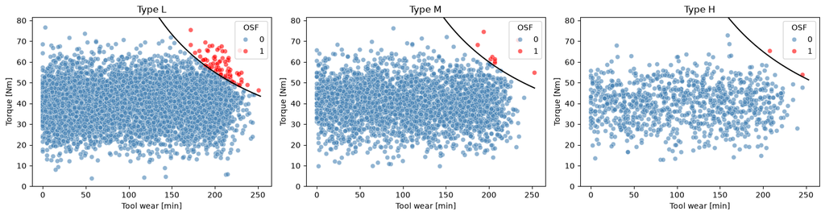

```python
import numpy as np
import matplotlib.pyplot as plt
import seaborn as sns

limits = {"L": 11000, "M": 12000, "H": 13000}       #Grenzwerde festlegen

fig, axes = plt.subplots(1, 3, figsize=(15, 4))     #Drei Subplots vorbereiten

for ax, product_type in zip(axes, limits):          #Produkttypen durchlaufen
    data = df[df["Type"] == product_type]

    #Datenpunkte plotten
    sns.scatterplot(
        data=data,
        x="Tool wear [min]",
        y="Torque [Nm]",
        hue="OSF",                              #Farbe nach OSF (0 oder 1) unterscheiden
        palette={0: "steelblue", 1: "red"},     #Punktfarbe festlegen
        alpha=0.6,
        ax=ax
    )

    #Grenzwerte für die Kurve berechnen und plotten
    wear = np.linspace(1, df["Tool wear [min]"].max(), 300)
    ax.plot(wear, limits[product_type] / wear, color="black")

    ax.set_ylim(0, df["Torque [Nm]"].max() + 5)
    ax.set_title(f"Type {product_type}")

plt.tight_layout()
plt.show()
```

# In Section 13.1.6.2, the decision tree of depth 3 was not able to model OSF, since a decision tree can only split along one feature at a time (horizontal or vertical cuts). A product such as torque times tool wear can only be approximated by a staircase of such cuts. This is where domain knowledge comes into play: a well-chosen feature can turn a hard problem into a trivial one.

1. Visualize the limitation: train decision trees of depth 1, 2, 4, and 8 on Torque [Nm] and Tool wear [min] only, with OSF as target. Plot the resulting decision boundaries using sklearn.inspection.DecisionBoundaryDisplay and compare them to the hyperbola torque x tool wear = 11,000.

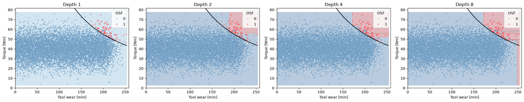

```python
from sklearn.tree import DecisionTreeClassifier
from sklearn.inspection import DecisionBoundaryDisplay

X = df[["Tool wear [min]", "Torque [Nm]"]]      #Merkmale für den Baum festlegen
y = df["OSF"]                                   #Ergebnisvariable für den Baum festlegen

fig, axes = plt.subplots(1, 4, figsize=(20, 4))          #Plot vorbereiten

for ax, depth in zip(axes, [1, 2, 4, 8]):                               #Tiefe der Entscheidungsbäume durchlaufen
    tree = DecisionTreeClassifier(max_depth=depth, random_state=42)     #max_depth = Tiefe des Baums festlegen
    tree.fit(X, y)                                                      #Baum auf den Daten fitten

    #Entscheidungsgrenzen plotten
    DecisionBoundaryDisplay.from_estimator(
        tree,                           #Estimator = Baum
        X,                              #Bestimmungsvariablen
        response_method="predict",      #Stellt die vorhergesagten Klassen dar (0 oder 1)
        cmap="RdBu_r",                  #Farbpalette für die Entscheidungsgrenzen
        alpha=0.3,                      #Hintergrundtransparenz
        grid_resolution=300,            #Auflösung des Gitters für die Darstellung der Entscheidungsgrenzen
        ax=ax
    )

    # Tatsächliche Datenpunkte plotten
    sns.scatterplot(
        data=df,
        x="Tool wear [min]",
        y="Torque [Nm]",
        hue="OSF",
        palette={0: "steelblue", 1: "red"},
        s=10,
        alpha=0.5,
        ax=ax
    )

    # Grenzkurve L plotten
    wear = np.linspace(1, X["Tool wear [min]"].max(), 300)
    ax.plot(wear, 11000 / wear, color="black")

    ax.set_xlim(0, X["Tool wear [min]"].max() + 5)
    ax.set_ylim(0, X["Torque [Nm]"].max() + 5)
    ax.set_title(f"Depth {depth}")

plt.tight_layout()
plt.show()
```

Der Entscheidungsbaum mit Tiefe 1 sagt für den gesamten dargestellten Bereich keinen OSF-Ausfall voraus. Obwohl eine Aufteilung möglich ist, überwiegen in beiden entstehenden Bereichen die Beobachtungen ohne OSF.

Ab Tiefe 2 erkennt der Baum einen Bereich mit hohem Werkzeugverschleiß und hohem Drehmoment als OSF. Mit zunehmender Tiefe wird die Entscheidungsgrenze feiner und nähert sich der gekrümmten Grenze stufenweise an. Da ein Entscheidungsbaum immer nur nach einem Merkmal gleichzeitig aufteilt, entstehen ausschließlich waagerechte und senkrechte Grenzen.

Bei Tiefe 8 sind viele kleine Aufteilungen sichtbar, die auf eine stärkere Anpassung an die Trainingsdaten hindeuten. Die schwarze Kurve gilt außerdem nur für Produktvariante L, während die Diagramme alle drei Varianten enthalten.

2. Engineer the feature wearadjTorque and retrain the tree from Section 13.1.6.2 with wearadjTorque = Torque x Tool wear as an additional feature. How does the structure of the tree change?

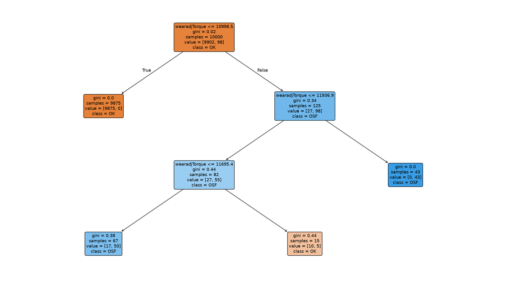

```python
import numpy as np
import matplotlib.pyplot as plt
import sklearn.tree as skt

# Berechnung zusätzlicher Merkmale
df["temp_diff"] = df["Process temperature [K]"] - df["Air temperature [K]"]
df["power"] = df["Torque [Nm]"] * df["Rotational speed [rpm]"] * 2 * np.pi / 60
df["wearadjTorque"] = df["Tool wear [min]"] * df["Torque [Nm]"]

# Definition der Merkmale und Zielvariable
features = [
    "Air temperature [K]",
    "Process temperature [K]",
    "Rotational speed [rpm]",
    "Torque [Nm]",
    "Tool wear [min]",
    "temp_diff",
    "power",
    "wearadjTorque"
]

X = df[features]
y = df["OSF"]

# Erstellung und Training des Entscheidungsbaums
tree = skt.DecisionTreeClassifier(
    max_depth=3,            #maximale Tiefe des Baums
    random_state=42,        #Zufallszahlengenerator für Reproduzierbarkeit
    min_samples_split=5,    #minimale Anzahl an Samples, die benötigt werden, um einen Knoten zu teilen
    min_samples_leaf=5      #minimale Anzahl an Samples in einem Blattknoten
)

# Training des Baums auf den Daten
tree.fit(X, y)

plt.figure(figsize=(18, 10), dpi=120)

skt.plot_tree(
    tree,
    feature_names=features,
    class_names=["OK", "OSF"],
    filled=True,
    rounded=True,
    fontsize=11,
    precision=2
)

plt.tight_layout()
plt.show()
```

Mit dem zusätzlichen Merkmal wearadjTorque verwendet der Entscheidungsbaum bei allen Aufteilungen nur noch das Produkt aus Werkzeugverschleiß und Drehmoment. Die zuvor getrennten Abfragen beider Merkmale werden dadurch ersetzt.

Bereits die erste Aufteilung bei 10.998,5 min·Nm trennt 9.875 Beobachtungen ohne OSF von einem Bereich mit allen 98 OSF-Ausfällen. Der gelernte Schwellenwert liegt damit nahe an der vorgegebenen Grenze von 11.000 min·Nm für Produktvariante L.

Eine vollständige Trennung gelingt noch nicht: Auf den Trainingsdaten werden 17 Beobachtungen fälschlich als OSF eingeordnet und 5 Ausfälle übersehen. Die Produktvariante und ihre unterschiedlichen Grenzwerte werden bisher nicht ausdrücklich berücksichtigt.

3. The threshold depends on the product variant Type. Also make this a feature.

```python
# Festlegung der Grenzwerte für die verschiedenen Produkttypen
limits = {"L": 11000, "M": 12000, "H": 13000}

# Zuordnung der Grenzwerte basierend auf dem Produkttyp
df["osf_limit"] = df["Type"].map(limits)
# Berechnung der relativen Belastung (Belastung Skaliert mit dem Grenzwert)
df["relative_load"] = df["wearadjTorque"] / df["osf_limit"]

df[["Type", "wearadjTorque", "osf_limit", "relative_load", "OSF"]].head()
```

|  | Type | wearadjTorque | osf_limit | relative_load | OSF |
| --- | --- | --- | --- | --- | --- |
| 0 | M | 0.0 | 12000 | 0.000000 | 0 |
| 1 | L | 138.9 | 11000 | 0.012627 | 0 |
| 2 | L | 247.0 | 11000 | 0.022455 | 0 |
| 3 | L | 276.5 | 11000 | 0.025136 | 0 |
| 4 | L | 360.0 | 11000 | 0.032727 | 0 |

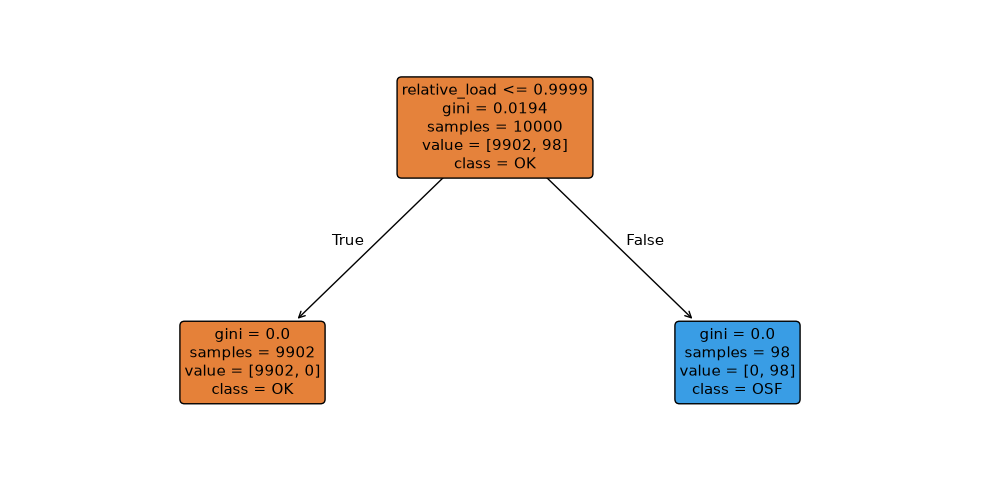

```
Falsch eingeordnete Beobachtungen: 0
Gelernter Schwellenwert: 0.9998636245727539
```

```python
X = df[["relative_load"]]       #Merkmale für den Baum festlegen (Nur sklalierte Belastung)
y = df["OSF"]                   #Ergebnisvariable für den Baum festlegen

# Erstellung und Training des Entscheidungsbaums
tree = skt.DecisionTreeClassifier(
    max_depth=1,            #maximale Tiefe des Baums
    random_state=42,
    min_samples_split=5,
    min_samples_leaf=5
)

# Training des Baums auf den Daten
tree.fit(X, y)

# Anzeige des Entscheidungsbaums
plt.figure(figsize=(10, 5))

skt.plot_tree(
    tree,
    feature_names=["relative_load"],
    class_names=["OK", "OSF"],
    filled=True,
    rounded=True,
    fontsize=11,
    precision=4
)

plt.tight_layout()
plt.show()

prediction = tree.predict(X)

print("Falsch eingeordnete Beobachtungen:", (prediction != y).sum())
print("Gelernter Schwellenwert:", tree.tree_.threshold[0])
```

4. What is the smallest tree depth that separates OSF (almost) perfectly, and which threshold does the tree learn?

Um die unterschiedlichen Grenzwerte der Produktvarianten zu berücksichtigen, wurde wearadjTorque durch den jeweiligen Grenzwert geteilt: 11.000 für L, 12.000 für M und 13.000 für H. Das neue Merkmal relative_load beschreibt damit die Belastung im Verhältnis zum zulässigen Grenzwert.

Mit diesem Merkmal reicht bereits ein Entscheidungsbaum der Tiefe 1 aus. Der gelernte Schwellenwert beträgt etwa 0,99986 und entspricht damit nahezu der erwarteten Grenze von 1. Alle 9.902 Beobachtungen ohne OSF und alle 98 OSF-Ausfälle werden auf den Trainingsdaten korrekt getrennt.

Die Vereinfachung gelingt, weil die bekannten Zusammenhänge einschließlich der produktspezifischen Grenzwerte bereits in das neue Merkmal eingebaut wurden.

After this exercise you should be able to:

1. Explain why decision trees struggle with interactions and rotated decision boundaries.
2. Use domain knowledge to engineer features that simplify a model.
1. Entscheidungsbäume teilen bei jeder Entscheidung anhand eines einzelnen Merkmals auf. Dadurch entstehen achsenparallele, also waagerechte oder senkrechte Grenzen. Hängt ein Fehler vom Zusammenspiel mehrerer Merkmale ab, können schräge oder gekrümmte Grenzen entstehen. Diese kann ein Baum nur durch viele treppenartige Aufteilungen annähern.
2. Mit Fachwissen lassen sich Merkmale bilden, die solche Zusammenhänge direkt ausdrücken. Für OSF haben wir Werkzeugverschleiß und Drehmoment zu wearadjTorque multipliziert. Durch die anschließende Division durch den produktspezifischen Grenzwert entstand relative_load. Damit genügte ein Baum der Tiefe 1 mit einem Schwellenwert nahe 1, um die Trainingsdaten vollständig zu trennen.

HTML erstellt mit:

uv run jupyter nbconvert --to html "Tasks/14 Self study - Session 1/Exercise_14.2.ipynb"